# Project 3: NLP Classifying Text

#### Austin Chan, Justin Herman, Chester Poon, Deepak Mongia, Michael O'Donnell

## Introduction

For this project, we were to take an example from our book *Natural Language Processing with Python* on name classification and take that example/exercise further and develop a "well-working" model. However, we decided to push ourselves a bit more. We not only built a name-gender classification model, but we also built a democrat/republican classification model from a dataset of political tweets by members of congress, which is available on Kaggle.

Name Classification

[Tweet Classification](https://github.com/justinherman42/Data620/blob/master/project3/Political_Tweet_Classification.ipynb)

## Name Classification

[Link to Jupyter Notebook for Name Classification in github repo](https://github.com/chesterpoon8/CUNY-Data620/blob/master/Project3.ipynb)

[Link to Youtube video for Name Classification Portion](https://youtu.be/F60obB3ssWQ)

### The Plan

- Load our dataset and do some very simple exploratory analysis.
- Develop our feature set using a constructor to add features with greater ease and code readability.
- Validate the accuracy of our model by observing the accuracy scores.
- Systematically add features and evaluate accuracy score of the model and of a custom name list we created.
- Addressing Model Quality and determine which features to add/keep.
- Concluding thoughts.

### Loading in our packages

Our dataset for names comes from `nltk.corpus`. The other packages we use will help us replicate the methods used in the book as well as to explore the data.

```python
from nltk.corpus import names
import nltk
import random
import numpy as np
import pandas as pd
import seaborn as sns
import statistics
import matplotlib.pyplot as plt

sns.set_style("darkgrid")
```

### Exploring Our Data

First, we'll take a look at some basic information about our dataset. We'll convert our data into formats we can use.

```python
f = len(names.words('female.txt'))
m = len(names.words('male.txt'))

#Similiar to the book, we convert the data into a list of tuples.
#This also makes it easier to feed into our pandas dataframe below.
names = ([(name, 'M') for name in names.words('male.txt')] +
         [(name, 'F') for name in names.words('female.txt')])
random.shuffle(names)

#We also convert to a pandas dataframe for ease of use in exploring our data.
names_df = pd.DataFrame(names, columns=['name','gender'])
pie = pd.DataFrame(names_df.gender.value_counts())
pie
```

|  | gender |
| --- | --- |
| F | 5001 |
| M | 2943 |

```
7944 total names.
```

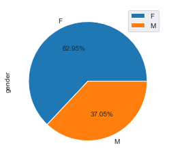

```python
print(str(m+f) + " total names.")
pie.plot(kind='pie', y='gender', autopct='%1.2f%%')
plt.show()
```

### Developing the Features for Our Model

The class we created below instantiates with a default feature of the last letter of the name. It also can return a dictionary of features for a single name we feed into it. This will allow us to classify a single name for later use. We will default with the name "John", but this can be repaced.

### Create the Feature Constructor

Our feature constructor will default with one feature when instantiated: last letter of the name. There will be methods in the constructor to call for the following features to be added:

- First Letter
- First 2 Letters
- Last 2 Letters
- First 3 Letters
- Last 3 Letters
- First 4 Letters
- Last 4 Letters
- Length

The constructor when called will then return a feature set that can be used for classification and modeling.

```python
class GenFeat:
    def __init__(self, names=None, Name=['John','Jane']):
        self.featureset = []
        self.names = names
        self.Name = Name
        self.classifierset = []
        self.__adding_feat()

    def featuresets(self):
        return self.featureset

    def __feat_start(self, name):
        features = {}
        features["lastletter"] = name[-1].lower()
        return features

    def __adding_feat(self):
        for (n,g) in self.names:
            self.featureset.append((self.__feat_start(n), g))
        for n in self.Name:
            self.classifierset.append({"lastletter": n[-1].lower()})

    def firstletter(self):
        for i in range(len(self.names)):
            self.featureset[i][0].update({'firstletter': self.names[i][0][0].lower()})
        for i in range(len(self.Name)):
            self.classifierset[i].update({'firstletter': self.Name[i][0].lower()})

    def length(self):
        for i in range(len(self.names)):
            self.featureset[i][0].update({'length': len(self.names[i][0])})
        for i in range(len(self.Name)):
            self.classifierset[i].update({'length': len(self.Name[i])})

    def first2(self):
        for i in range(len(self.names)):
            self.featureset[i][0].update({'first2': self.names[i][0][:2].lower()})
        for i in range(len(self.Name)):
            self.classifierset[i].update({'first2': self.Name[i][:2].lower()})

    def last2(self):
        for i in range(len(self.names)):
            self.featureset[i][0].update({'last2': self.names[i][0][-2:].lower()})
        for i in range(len(self.Name)):
            self.classifierset[i].update({'last2': self.Name[i][-2:].lower()})

    def first3(self):
        for i in range(len(self.names)):
            try:
                self.featureset[i][0].update({'first3': self.names[i][0][:3].lower()})
            except:
                self.featureset[i][0].update({'first3': self.names[i][0][:2].lower()})
        for i in range(len(self.Name)):
            try:
                self.classifierset[i].update({'first3': self.Name[i][:3].lower()})
            except:
                self.classifierset[i].update({'first3': self.Name[i][:2].lower()})

    def last3(self):
        for i in range(len(self.names)):
            try:
                self.featureset[i][0].update({'last3': self.names[i][0][-3:].lower()})
            except:
                self.featureset[i][0].update({'last3': self.names[i][0][-2:].lower()})
        for i in range(len(self.Name)):
            try:
                self.classifierset[i].update({'last3': self.Name[i][-3:].lower()})
            except:
                self.classifierset[i].update({'last3': self.Name[i][-2:].lower()})

    def first4(self):
        for i in range(len(self.names)):
            try:
                self.featureset[i][0].update({'first4': self.names[i][0][:4].lower()})
            except:
                self.featureset[i][0].update({'first4': self.names[i][0][:2].lower()})
        for i in range(len(self.Name)):
            try:
                self.classifierset[i].update({'first4': self.Name[i][:4].lower()})
            except:
                self.classifierset[i].update({'first4': self.Name[i][:2].lower()})

    def last4(self):
        for i in range(len(self.names)):
            try:
                self.featureset[i][0].update({'last4': self.names[i][0][-4:].lower()})
            except:
                self.featureset[i][0].update({'last4': self.names[i][0][-2:].lower()})
        for i in range(len(self.Name)):
            try:
                self.classifierset[i].update({'last4': self.Name[i][-4:].lower()})
            except:
                self.classifierset[i].update({'last4': self.Name[i][-2:].lower()})

    def classify(self):
        return self.classifierset
```

Now that our feature constructor is ready, we can build our feature set for each name and feed it into our model. The project instructions request that we split the data into 500 for the test set, 500 for the dev test set, and the remaining names for the training set. We'll also build out our model into a single function.

After some testing and trial/error to see which model would be best, it appears that a Naive Bayes classifier would be the most appropriate.

### Validating Accuracy

After multiple trials of tinkering, we noticed that occasionally on reshuffling of the names, there would be relatively significant discrepancies between our test set and development test set. Typically we should see approximately the same accuracy score for our test set and development test set. In order to determine the best features, we attempted to get a mean accuracy score to evaluate which features would be the most appropriate for our model. More on this soon.

Let's first create our function that splits the data, fits to a classifier, and returns an accuracy score.

```python
def nltk_pred(f):
    #Split the data
    featuresets = f.featuresets()
    train_set, test_set = featuresets[1000:], featuresets[:1000]
    a_train_set, a_test_set, a_test_dev_set = featuresets[1000:], featuresets[:500], featuresets[500:1000]

    #Code for applying our method for validating accuracy
    classifier = nltk.NaiveBayesClassifier.train(train_set)
    acc_score = nltk.classify.accuracy(classifier, test_set)

    #Code for assignment
    a_classifier = nltk.NaiveBayesClassifier.train(a_train_set)
    a_acc_score = nltk.classify.accuracy(a_classifier, a_test_set)
    a_acc_score_dev = nltk.classify.accuracy(classifier, a_test_dev_set)
    return classifier, acc_score, a_classifier, a_acc_score, a_acc_score_dev
```

Now we can instantiate our feature constructor and start building out our model. We'll start with the default, which is just the last letter of the names. We'll also load a names list to classify individual names.

```python
name_list = ['Jane','John','Michael','Michelle','Steven','Laura','Jerry','Joan']
f_obj = GenFeat(names=names,Name=name_list)
```

Let's now find the accuracy scores for our test set and our development test set.

```python
print("Accuracy score on our test set is " + str(nltk_pred(f_obj)[3]*100)+"%")
print("Accuracy score on our development test set is " + str(nltk_pred(f_obj)[4]*100)+"%")
```

```
Accuracy score on our test set is 75.2%
Accuracy score on our development test set is 79.60000000000001%
```

Depending on the specific model created from our training set, the accuracy scores between our test set and development set can either be about the same or very different. More on this later.

### Working with Our Features and Classifying Individual Names

We'll create a function here that can classify a list of names we feed into our model. This will also show an accuracy score for a model in its current state.

```python
acc_score_single = []
def classifier(f):
    for i in range(len(f.classify())):
        print(name_list[i] + " = " + nltk_pred(f)[0].classify(f.classify()[i]))
    print("Accuracy score for this model is " + str(nltk_pred(f)[1]*100)+"%")
    print("-----------------------------------------------")
    acc_score_single.append(nltk_pred(f)[1])
```

Now that our classifier has been created, let's see how it performs as we add features.

#### Default single feature: Last Letter

```python
classifier(f_obj)
```

```
Jane = F
John = M
Michael = M
Michelle = F
Steven = M
Laura = F
Jerry = F
Joan = M
Accuracy score for this model is 77.4%
-----------------------------------------------
```

Not bad, but we can definitely improve on this model. The model has also categorized Joan and Jerry incorrectly. Let's try adding the first letter of each name.

#### Features:

- Last Letter
- First Letter

```python
f_obj.firstletter()
classifier(f_obj)
```

```
Jane = F
John = M
Michael = F
Michelle = F
Steven = M
Laura = F
Jerry = F
Joan = M
Accuracy score for this model is 77.9%
-----------------------------------------------
```

Our accuracy score is better, but for our particular list, we've now incorrectly categorized Michael. Let's keep adding features.

#### Features

- Last Letter
- First Letter
- First 2 Letters

```python
f_obj.first2()
classifier(f_obj)
```

```
Jane = F
John = M
Michael = F
Michelle = F
Steven = M
Laura = F
Jerry = F
Joan = M
Accuracy score for this model is 79.2%
-----------------------------------------------
```

#### Features

- Last Letter
- First Letter
- First 2 Letters
- Last 2 Letters

```python
f_obj.last2()
classifier(f_obj)
```

```
Jane = F
John = M
Michael = F
Michelle = F
Steven = M
Laura = F
Jerry = M
Joan = M
Accuracy score for this model is 82.0%
-----------------------------------------------
```

#### Features

- Last Letter
- First Letter
- First 2 Letters
- Last 2 Letters
- First 3 Letters

```python
f_obj.first3()
classifier(f_obj)
```

```
Jane = F
John = M
Michael = M
Michelle = F
Steven = M
Laura = F
Jerry = M
Joan = M
Accuracy score for this model is 84.2%
-----------------------------------------------
```

#### Features

- Last Letter
- First Letter
- First 2 Letters
- Last 2 Letters
- First 3 Letters
- Last 3 Letters

```python
f_obj.last3()
classifier(f_obj)
```

```
Jane = F
John = M
Michael = M
Michelle = F
Steven = M
Laura = F
Jerry = M
Joan = M
Accuracy score for this model is 85.2%
-----------------------------------------------
```

#### Features

- Last Letter
- First Letter
- First 2 Letters
- Last 2 Letters
- First 3 Letters
- Last 3 Letters
- First 4 Letters

```python
f_obj.first4()
classifier(f_obj)
```

```
Jane = F
John = M
Michael = M
Michelle = F
Steven = M
Laura = F
Jerry = M
Joan = F
Accuracy score for this model is 86.1%
-----------------------------------------------
```

The names in our list are all now correctly classified and we now have a decent accuracy score. We didn't add the length feature or the last 4 letters feature primarily due to overfitting.

Let's take a quick look to see how our model improved with each added feature.

|  | score | No. of Features |
| --- | --- | --- |
| 0 | 0.774 | 1 |
| 1 | 0.779 | 2 |
| 2 | 0.792 | 3 |
| 3 | 0.820 | 4 |
| 4 | 0.842 | 5 |
| 5 | 0.852 | 6 |
| 6 | 0.861 | 7 |

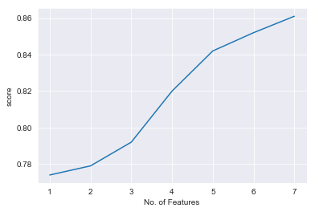

```python
def acc_plot_single():
    improvements = pd.DataFrame(acc_score_single, columns=['score'])
    improvements['No. of Features'] = improvements.index + 1
    sns.lineplot(x=improvements['No. of Features'],
                 y=improvements.score)
    return improvements
    plt.show()

acc_plot_single()
```

Depending on the random shuffle and how the training set was developed, we might see a dip in quality of our model from a particular feature. We can use the method we discuss below to decide whether we should include it.

### Different Shufflings of Dataset Affecting Model Quality

A problem that we ran into was the variance involved with our accuracy scores while testing our model. It appeared that the quality of the model can depend on how the training, test, and development sets are split. In other words, by chance if the names a shuffled in a certain way, we can obtain better or worse results. To get a clearer picture to see if there is indeed a difference between the development test set and the test set, we'll randomly shuffle our dataset 500 times to obtain a new randomized test set and development set each time and evaluate the quality and difference between the two.

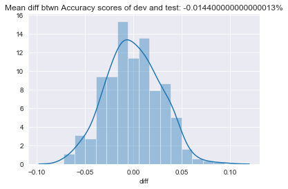

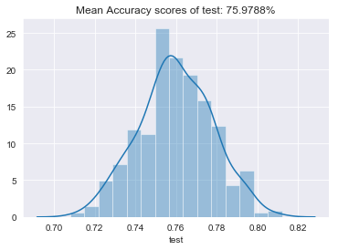

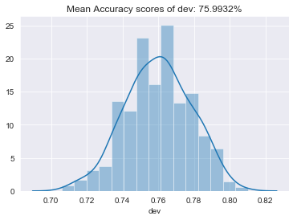

```python
nltk_nb_test = []
nltk_nb_dev = []
#Reshuffle the names each time to find distribution of accuracy scores
for i in range(500):
    random.shuffle(names)
    f_samp = GenFeat(names=names)
    nltk_nb_test.append(nltk_pred(f_samp)[3])
    nltk_nb_dev.append(nltk_pred(f_samp)[4])

df = pd.DataFrame({'test': nltk_nb_test,
                   'dev': nltk_nb_dev})
df['diff'] = df.test - df.dev

#Function for histogram plots
def acc_plot(title_txt, scores):
    plt.title(title_txt +
              str(statistics.mean(scores)*100)+"%")
    sns.distplot(scores,bins=15)
    plt.show()

acc_plot("Mean diff btwn Accuracy scores of dev and test: ", df['diff'])
acc_plot("Mean Accuracy scores of test: ", df['test'])
acc_plot("Mean Accuracy scores of dev: ", df['dev'])
```

As we can see, the difference between means hovers around 0 and the scores for both the test set and the development set are nearly identical. We'll employ the same method above as we deploy our model and evaluate best features to include.

#### Features

- Last Letter

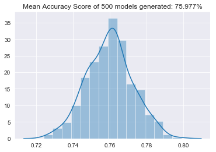

```python
acc_score_single = []
nltk_nb_scores = []

#Reshuffle the names each time to find distribution of accuracy scores
for i in range(500):
    random.shuffle(names)
    f_samp = GenFeat(names=names)
    nltk_nb_scores.append(nltk_pred(f_samp)[1])

acc_score_single.append(statistics.mean(nltk_nb_scores))
acc_plot("Mean Accuracy Score of 500 models generated: ", nltk_nb_scores)
```

#### Features

- Last Letter
- First Letter

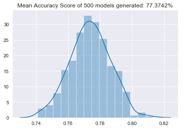

```python
nltk_nb_scores = []
#Reshuffle the names each time to find distribution of accuracy scores
for i in range(500):
    random.shuffle(names)
    f_samp = GenFeat(names=names)
    f_samp.firstletter()
    nltk_nb_scores.append(nltk_pred(f_samp)[1])

acc_score_single.append(statistics.mean(nltk_nb_scores))
acc_plot("Mean Accuracy Score of 500 models generated: ", nltk_nb_scores)
```

#### Features

- Last Letter
- First Letter
- First 2 Letters

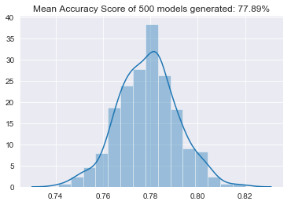

```python
nltk_nb_scores = []
#Reshuffle the names each time to find distribution of accuracy scores
for i in range(500):
    random.shuffle(names)
    f_samp = GenFeat(names=names)
    f_samp.firstletter()
    f_samp.first2()
    nltk_nb_scores.append(nltk_pred(f_samp)[1])

acc_score_single.append(statistics.mean(nltk_nb_scores))
acc_plot("Mean Accuracy Score of 500 models generated: ", nltk_nb_scores)
```

#### Features

- Last Letter
- First Letter
- First 2 Letters
- Last 2 Letters

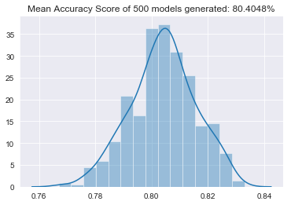

```python
nltk_nb_scores = []
#Reshuffle the names each time to find distribution of accuracy scores
for i in range(500):
    random.shuffle(names)
    f_samp = GenFeat(names=names)
    f_samp.firstletter()
    f_samp.first2()
    f_samp.last2()
    nltk_nb_scores.append(nltk_pred(f_samp)[1])

acc_score_single.append(statistics.mean(nltk_nb_scores))
acc_plot("Mean Accuracy Score of 500 models generated: ", nltk_nb_scores)
```

#### Features

- Last Letter
- First Letter
- First 2 Letters
- Last 2 Letters
- First 3 Letters

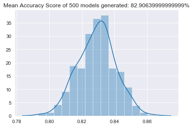

```python
nltk_nb_scores = []
#Reshuffle the names each time to find distribution of accuracy scores
for i in range(500):
    random.shuffle(names)
    f_samp = GenFeat(names=names)
    f_samp.firstletter()
    f_samp.first2()
    f_samp.last2()
    f_samp.first3()
    nltk_nb_scores.append(nltk_pred(f_samp)[1])

acc_score_single.append(statistics.mean(nltk_nb_scores))
acc_plot("Mean Accuracy Score of 500 models generated: ", nltk_nb_scores)
```

#### Features

- Last Letter
- First Letter
- First 2 Letters
- Last 2 Letters
- First 3 Letters
- Last 3 Letters

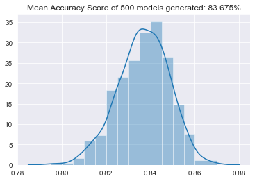

```python
nltk_nb_scores = []
#Reshuffle the names each time to find distribution of accuracy scores
for i in range(500):
    random.shuffle(names)
    f_samp = GenFeat(names=names)
    f_samp.firstletter()
    f_samp.first2()
    f_samp.last2()
    f_samp.first3()
    f_samp.last3()
    nltk_nb_scores.append(nltk_pred(f_samp)[1])

acc_score_single.append(statistics.mean(nltk_nb_scores))
acc_plot("Mean Accuracy Score of 500 models generated: ", nltk_nb_scores)
```

#### Features

- Last Letter
- First Letter
- First 2 Letters
- Last 2 Letters
- First 3 Letters
- Last 3 Letters
- First 4 Letters

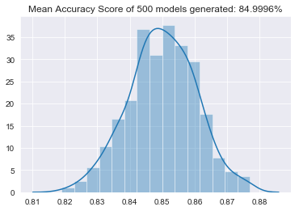

```python
nltk_nb_scores = []
#Reshuffle the names each time to find distribution of accuracy scores
for i in range(500):
    random.shuffle(names)
    f_samp = GenFeat(names=names)
    f_samp.firstletter()
    f_samp.first2()
    f_samp.last2()
    f_samp.first3()
    f_samp.last3()
    f_samp.first4()
    nltk_nb_scores.append(nltk_pred(f_samp)[1])

acc_score_single.append(statistics.mean(nltk_nb_scores))
acc_plot("Mean Accuracy Score of 500 models generated: ", nltk_nb_scores)
```

As before, we'll take a quick look to see how the mean accuracy score improved with each added feature.

|  | score | No. of Features |
| --- | --- | --- |
| 0 | 0.759770 | 1 |
| 1 | 0.773742 | 2 |
| 2 | 0.778900 | 3 |
| 3 | 0.804048 | 4 |
| 4 | 0.829064 | 5 |
| 5 | 0.836750 | 6 |
| 6 | 0.849996 | 7 |

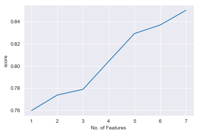

```python
acc_plot_single()
```

### Conclusion

To recap, the features we added/kept that were effective in improving the model are:

*Click to view process of addition of feature*

- Last Letter
- First Letter
- First 2 Letters
- Last 2 Letters
- First 3 Letters
- Last 3 Letters
- First 4 Letters

It can be argued that the increase in score from adding the `First 2 Letters` feature is so negligible, that it could be removed. From our testing of 500 different models on randomized names, we were able to determine that although the improvement was small, it was still a consistent improvement and would make sense to include it. Our accuracy score for our model with the features listed above is approximately 85%.